# Exercise 2

# Exercise 4

As you see the same is done for each filter. The data types returned are `uint8`. As you can also see there is no difference between the different versions. The first one is using a convolution like before a 2d mask over a 3 channel image. Broadcasting and vectorization solve all the problems of applying the filter to each channel. The second filter does a convolution for each channel. The fact that both filters give the same result makes it not really neccesary at all to writte another version of the filter for 3 channel color images.

```python
def gaussianFilterKernelSepColor(im, sigma=5):
    gv1d = signal.windows.gaussian(2 * round(4.0 * sigma) + 1, sigma).reshape(2 * round(4.0 * sigma) + 1, 1, 1)
    maskv = np.divide(gv1d, np.sum(gv1d))
    maskh = maskv.reshape(1, 2 * round(4.0 * sigma) + 1, 1)
    im2 = ndimage.convolve(im, maskv, "float64")
    return ndimage.convolve(im2, maskh, "uint8")
```

```python
def gaussianFilterKernelSepColor2(im, sigma=5):
    gv1d = signal.windows.gaussian(2 * round(4.0 * sigma) + 1, sigma).reshape(2 * round(4.0 * sigma) + 1, 1)
    maskv = np.divide(gv1d, np.sum(gv1d))
    maskh = maskv.T
    im2 = im.copy()
    for i in range(3):
        im2[:, :, i] = ndimage.convolve(im2[:, :, i], maskv, "float64")
        im2[:, :, i] = ndimage.convolve(im2[:, :, i], maskh, "float64")
    return im2.astype('uint8')
```

```python
def addGaussianNoise(im, sd=5):
    return im + np.random.normal(loc=0, scale=sd, size=im.shape)
```

As you see this time we don't change the data type after adding gaussian noise, beacuse gaussian noise is real valued (`float64` data type).

```
4 None None
```

[figure not shown]

```python
im = np.array(Image.open('./imgs-P2/girl.ppm').convert('RGB')) # Use Lena image read as an RGB image with 3 channels
im2 = addGaussianNoise(im) # We don't change the data type
im3 = gaussianFilterKernelSepColor(im2, 2)
im4 = gaussianFilterKernelSepColor2(im2, 2)
vpu.showInGrid([im,im2.astype('uint8'),im3,im4], figure_size, title = "Convolve with: ",subtitles=["Original", "With Gaussian noise", "Convolve all the image", "Convolve each channel"])
```

```python
# No difference on the images arrays, between convolution for each channel and covolution for the entire image.
im3[im4!=im3]
```

```
array([], dtype=uint8)
```

# Exercise 5

This is an interesting exercise. I think that the quotient might be useful for looking object shapes as you can see their edges more prominent after applying the filter.

```python
def quotientImage(im, sigma = 5):
    return np.divide(im, gaussianFilterKernelSep(im, sigma))
```

```
2 None None
```

[figure not shown]

```python
im = np.array(Image.open('./imgs-P2/lena256.pgm'))
im2 = quotientImage(im)
vpu.showInGrid([im,im2], figure_size, subtitles=["Original", "Quotient"])
```

# Exercise 6

It is already implemented. There is already the subtitles argument in showInGrid. What I think would be interesting is an argument for setting the size of the plot. The size of the plot scales with the window size when using the given script, but I am using jupyter notebooks for its cleanness and easy to use when dealing with exercises and experimenting. I already implemented it.

And as for the mathematical expressions we can use some LaTeX expressions inside matplotlib without the need of an additional LaTeX instalation. https://matplotlib.org/stable/users/explain/text/mathtext.html

```python
def showInGrid(imgs, figure_size=None, m=None, n=None, title="", subtitles=None):
    N = len(imgs)
    # plt.subplots_adjust(top=5) # añadido (10/10/19) para ejecutar una entrega de un estudiante
    m, n = computeRowsCols(N, m, n)
    # print(m,n)
    if figure_size is None:
        figure_size = (m, n)
    fig = plt.figure(figsize=figure_size)
    plt.gray()
    for i in range(1, N + 1):
        ax = fig.add_subplot(m, n, i)
        if len(imgs[i - 1].shape) >= 2:
            plt.imshow(imgs[i - 1])
        else:
            plt.plot(imgs[i - 1])
        if subtitles is not None:
            ax.set_title(subtitles[i - 1])

    fig.suptitle(title)
    # plt.savefig(title+".png")#,bbox_inches='tight')
    plt.show(block=True)
```

# Exercise 7

It is easy to pass an argument with the two opossing vertex of the area we want to zoom in. Then the only thing left to do is to select the corresponding index of the image arrays.

There are many ways it can be improved, like cheking if the show argument is passed in a correct way or passing multiple vertex tuples one for each img in the imgs argument.

```python
def showInGrid(imgs, figure_size=None, m=None, n=None, show=None, title="", subtitles=None):
    N = len(imgs)
    # plt.subplots_adjust(top=5) # añadido (10/10/19) para ejecutar una entrega de un estudiante
    m, n = computeRowsCols(N, m, n)
    # print(m,n)
    if figure_size is None:
        figure_size = (m, n)
    # show is an argument that sets the two opossing vertex of the rectangle we want to zoom.
    if show is not None:
        for i in range(len(imgs)):
            imgs[i] = imgs[i][
                min(show[0][1], show[1][1]) : max(show[0][1], show[1][1]),
                min(show[0][0], show[1][0]) : max(show[0][0], show[1][0]),
            ]
    fig = plt.figure(figsize=figure_size)
    plt.gray()
    for i in range(1, N + 1):
        ax = fig.add_subplot(m, n, i)
        if len(imgs[i - 1].shape) >= 2:
            plt.imshow(imgs[i - 1])
        else:
            plt.plot(imgs[i - 1])
        if subtitles is not None:
            ax.set_title(subtitles[i - 1])

    fig.suptitle(title)
    # plt.savefig(title+".png")#,bbox_inches='tight')
    plt.show(block=True)
```

```
1 None None
```

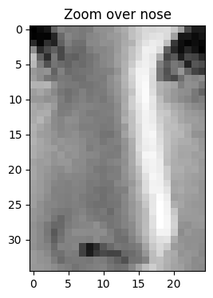

```python
im = np.array(Image.open('./imgs-P2/lena256.pgm'))
vpu.showInGrid([im], figure_size = (4,4), show=((140,165),(165,130)), subtitles=["Zoom over nose"])
```